# Topic 14

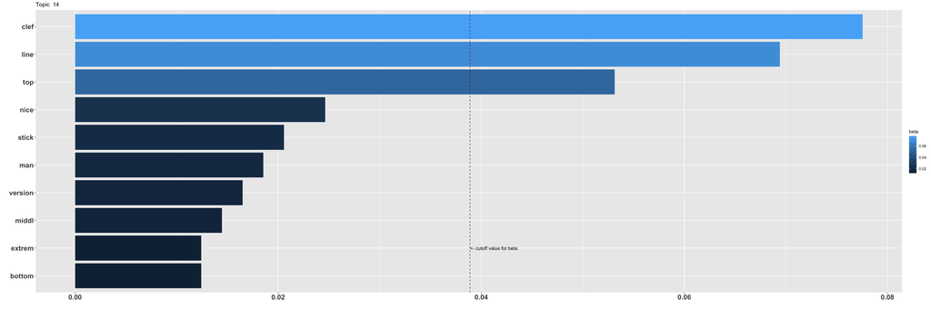

On interpreting beta: the term has a beta probability of being generated from the particular topic.

Values below are gamma : An estimated proportion of words from that document that are generated from that topic.

**Text Record Number: 280** gamma: 19 % likelihood of this document (based on its words) in this topic

**A common misconception is that treble clef means RH and bass clef means LH. In reality, they just indicate the general range of notes (think of it as bass clef for the lower half of the piano and treble for the upper half, which is why typically your LH will be bass and RH treble).

It’s safer to think of the top line as RH and the bottom line as LH, although even this isn’t always strictly true (there’ll still be instances where you might play notes in the bottom line with your RH and vice versa)

There are lots of other factors at play that will determine which hand is best to use for a certain section. In the case of bars 8 and 9 you would definitely use the LH for the bottom line due to the RH being busy with the octaves and unable to help out.**

**Text Record Number: 124** gamma: 19 % likelihood of this document (based on its words) in this topic

**I can remember Every Good boy does fine but remembering where the hell it’s applied has never stuck with me. But F A C E is the gaps on the top and A C E are the gaps at the bottom I remember these.

I usually just remember things by way of land marks and familiarity.

So Middle C is the line between the 2 staffs. B & D are the gaps below and above that. That makes the bottom line E.

The 2 dots on the bass surround F and the treble clef known as G clef is on G.

I know the E at the top mostly because what I’ve been trying to learn for 3 years has so many Es right there.**

**Text Record Number: 98** gamma: 19 % likelihood of this document (based on its words) in this topic

**It’s pretty easy to remember the treble clef 𝄞 ends in a spiral where it meets the G above middle C (i.e. the 2nd line from the bottom), and the bass clef does the same with F below middle C (2nd line from top). You can extrapolate from there to any other note you wish to identify, and soon learn the patterns (treble lines are E G B D F, handily all extensions of C major played on middle C), etc… Don’t know if this helps**

**Text Record Number: 491** gamma: 19 % likelihood of this document (based on its words) in this topic

**That’s normal starting out. People often give you acronyms like “Every Good Boy Does Fine” (treble clef lines), “All Cows Eat Grass” (bass clef spaces), or “FACE” (treble clef spaces) for stuff like that. I promise you’ll get a lot better as you go.

https://www.youtube.com/watch?v=jSOU-J9KHbg

This video is also VERY helpful**

**Text Record Number: 288** gamma: 19 % likelihood of this document (based on its words) in this topic

**I came across something very similar recently (I guess you mean where you suddenly have the treble clef down where the bass clef usually is)?

I’m a beginner so somebody more experienced should feel free to call me out!

I believe this is telling you that you will read the notes as if they were on the treble clef, but play with your left hand. When the bass clef symbol returns, all is ‘normal’ again.**

**Text Record Number: 150** gamma: 19 % likelihood of this document (based on its words) in this topic

**There are different approached but it all comes down to memorizing the lines and spaces.

One way is the FACE and Every Good Boy approach, but there is an alternate approach where you learn some key lines and spaces and recognize other from their relationship (how close or far away) to the key lines and spaces. This latter method is the one taught in this online course:

https://www.udemy.com/course/sight-reading/**

**Text Record Number: 157** gamma: 19 % likelihood of this document (based on its words) in this topic

**It’s just practice. There is no cheat. All you’re really teaching your brain to do, is to see a squiggle on a page and automatically know where your hand should be without thinking. You’ll learn the note names at the same time, some people think of FACE as the gaps on the treble clef, and ACEG on the bass clef, but really you’ll just know it over time without thinking and relying on memory tools. It’s a steep learning curve, but hit it and enjoy the benefits once familiar, took me 3 months to feel comfortable.

There are apps such as Complete Music Reading Trainer, I’d recommend avoiding stickers, but using them without putting any on the octaves either side of middle C wouldnt be too bad.**